# §2.3a — Why do we have Seasons?

Unit 2: The Night Sky · Astronomy

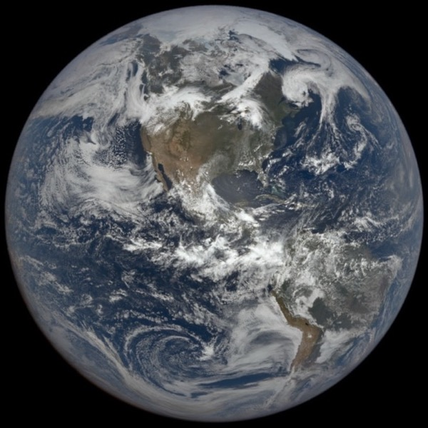

June 21

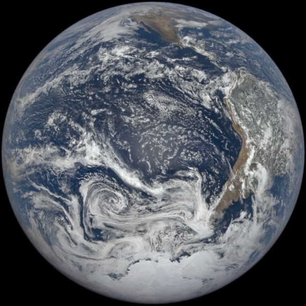

December 21

Two photos of Earth from a camera parked between us and the Sun, six months apart. In June the Arctic is tipped into the light. In December it is gone, and Antarctica is lit all the way round. NASA EPIC Team

In Portland, July is hot and January is cold. In Chile it is the other way round. Is that because we are closer to the Sun in summer?

Today: what really causes the seasons, why the Sun's height matters, and the five circles of latitude the Sun draws on the Earth.

## 1 · The seasons at a glance

🌍

23.5°

Tilt (obliquity)

Earth's axis is tipped from straight up off its orbit

☀️

±23.5°

δ of the Sun

from +23.5° on Jun 21 to −23.5° on Dec 21

📐

68° / 21°

Portland's noon Sun

on Jun 21 and Dec 21: more than three times as high

⏳

15h41m / 8h42m

Portland's daylight

on the longest and shortest days

🪐

January

Closest to the Sun

perihelion is Jan 3, in the middle of our winter

## 2 · Why do we have Seasons?

Click a tile.

[figure not shown]

1

The data

warmer or colder than usual

[figure not shown]

2

Which is correct?

proximity or tilt

[figure not shown]

3

Tilt changes δ⊙

the Sun's declination over a year

[figure not shown]

4

Sun transits at different altitude

θ max of the Sun

[figure not shown]

5

Why altitude matters

dilution and day length

[figure not shown]

6

Special circles

tropics, polar circles, equator

← scroll the tiles →

[figure not shown]

### The data

Every place on Earth has its own **average temperature** over a year. The map shows how much **warmer (red)** or **colder (blue)** than that average each place is in a given month. Hot places and cold places drop out; only the season is left.

Temperature compared with each place's own yearly average

Predict: in June, which half of the Earth is warmer than usual?

[interactive chart not shown]

colderwarmer than its yearly average

Month:

month

Make your prediction, then the map fills in.

Measure: read the map

Move the month to July and point at Portland. About how many degrees warmer than its yearly average is Portland in July?

°C

### Which is correct? Proximity or tilt

1. The Earth is actually closest to the Sun in January.
2. The Earth's orbit is only a few degrees off from a perfect circle.
3. The Tropics are warm all year.
4. The Seasons flip when you cross the equator.

Earth's orbit, drawn to scale

Predict: Earth is closest to the Sun in…

[interactive chart not shown]

date

Measure: how much more sunlight in January?

Sunlight falls off as $\frac{1}{d^2}$. Earth is $1.47\times10^{11}$ m from the Sun on Jan 3 and $1.52\times10^{11}$ m on Jul 5. In relative form, how many times more sunlight does Earth get in January?

times

### Tilt causes δ⊙ to change

Earth's axis always points at the same spot in the sky (the NCP, near Polaris) as Earth goes round the Sun. So for half the year the north is tipped toward the Sun, and for half the year away. Seen from Earth, the Sun slides along the ecliptic, and its **declination** swings from $\delta_\odot = +23.5^\circ$ to $-23.5^\circ$ and back.

Drag Earth, the axis or the graph: every view follows

Predict: on June 21, the North Pole is tipped…

[interactive chart not shown]

date

Show:

Ground:

Measure: read the graph

What is the declination of the Sun on the winter solstice, Dec 21?

°

### Sun transits at different altitude

The Sun is a "star" whose declination changes. It still transits on the meridian at noon, at the height you know from §2.2a:

$\boxed{\theta_{\rm max} = 90^\circ - |{\rm lat} - \delta_\odot|}$  
In the north, with the Sun south of the zenith, this is the same as $\theta = 90 - {\rm lat} + \delta$.

The Sun's path on three days

Predict: Portland's noon Sun on Dec 21 is about…

[interactive chart not shown]

Where:

time

Measure: another city

Anchorage, Alaska is at latitude $61^\circ$ N. How high is the noon Sun there on Jun 21?

°

**Look up on Mon Nov 30.** In Portland the Sun rises at 7:29 am, transits at 11:59 am only $23^\circ$ up, and sets at 4:29 pm: 9 hours of daylight. On Dec 21 it will be $21^\circ$ up at 12:08 pm, with 8 h 42 m of daylight. At noon, measure the shadow of a meter stick: on a low-Sun day it is more than twice the stick's length.

### Why does altitude matter? Two effects

**(1) Dilution.** Shine a flashlight straight down: a small bright spot. Tip it: the same light spreads over a bigger, dimmer patch. A 1-m bundle of sunlight smears over $\frac{1\ {\rm m}}{\sin\theta}$ of ground. **(2) Day length.** With the axis tipped toward the Sun, more of each northern circle of latitude is in daylight: more hours of heating.

(1) Dilution: a 1-m sunbeam

[interactive chart not shown]

θ

(2) Day length: spin the Earth

[interactive chart not shown]

City:

Show:

Measure: Portland in December

On Dec 21 Portland's noon Sun is $21^\circ$ up. Over how many meters of ground is a 1-m bundle of sunlight smeared?

m

### Special circles

The Sun draws five circles of latitude on the Earth. The **tropics** are where the Sun can go through the zenith. The **polar** circles are where the Sun can stay up all day, or not rise at all. Both are set by the tilt: tropics at $\pm 23.5^\circ$, polar circles at $\pm(90 - 23.5) = \pm 66.5^\circ$.

Earth from the side, Sun to the right

[interactive chart not shown]

date

Click a circle on the globe.

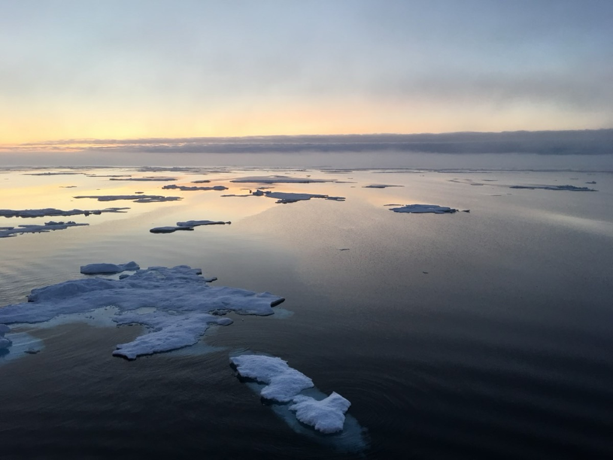

Midnight in July, north of the Arctic Circle: the Sun skims the horizon and never sets. Laura Gemery, USGS (public domain)

Next class: where on Earth the Sun is overhead, city by city: §2.3b.

Measure: the Arctic Circle in June

How high is the noon Sun at the Arctic Circle on Jun 21?

°

## 3 · Name that circle

Drag each name onto its line

[interactive chart not shown]

**Sources and further reading**

Want to dig deeper? Each title links straight to the original.

**The data**

- [NCEP/NCAR Reanalysis](https://psl.noaa.gov/data/gridded/data.ncep.reanalysis.html) (NOAA Physical Sciences Laboratory): the 30-year monthly averages (1991–2020) behind the temperature map.

**Proximity or tilt**

- [What causes the seasons?](https://spaceplace.nasa.gov/seasons/) (NASA Space Place): a short explainer with animations.
- [Perihelion and aphelion](https://en.wikipedia.org/wiki/Apsis) (Wikipedia): Earth's closest and farthest points, with the dates.
- [EPIC: Earth Polychromatic Imaging Camera](https://epic.gsfc.nasa.gov/) (NASA): a new photo of the whole sunlit Earth every couple of hours. Compare June and December yourself.

**The Sun's height and the special circles**

- [Circles of latitude](https://en.wikipedia.org/wiki/Circle_of_latitude) (Wikipedia): the equator, tropics and polar circles, and why they slowly move.
- [Midnight sun](https://en.wikipedia.org/wiki/Midnight_sun) (Wikipedia): what it looks like and where you can see it.
- [Midnight sun, Chukchi Sea](https://www.usgs.gov/media/images/midnight-sun-chukchi-sea) (USGS): the photo on this page, from a research ship in the Arctic.

**Tonight's sky**

- [Astronomy Engine](https://github.com/cosinekitty/astronomy) (Don Cross): the code that computed Portland's sunrise, noon Sun and the perihelion date.
- [Natural Earth](https://www.naturalearthdata.com/): the coastlines on the maps and globes.

**Image credits**

- Earth on Jun 21 and Dec 21, 2025: NASA EPIC Team, DSCOVR (public domain).
- Midnight sun over the Chukchi Sea: Laura Gemery, USGS (public domain).
- Temperature data provided by the NOAA PSL, Boulder, Colorado, USA, from their website at https://psl.noaa.gov (NCEP/NCAR Reanalysis 1).
- Coastlines: Natural Earth 1:110m land (public domain).
- All other figures are drawn on this page.